# Final Project

Kelly Cook

## First Responders Mental Health Awareness Survey

### Survey Data Analysis

#### Background

This survey is considered a “First Responders Mental Health Awareness Survey” or a Wellness and Support Questionnaire. It’s designed to give the administration a picture of how their department is doing based on their members’ self-reporting. The survey is broken up into sections measuring different areas of life first responders are typically most affected in.

#### Cleaning the data

Cleaning the raw data was an extencive work. This particular data sets department membership has 545 sworn officers, 119 civilian members (non-officers). 324 responded (but not to every question)-approximately 48.80% response rate.There is an .Rproj in this folder that contains the primary cleaning. The data will be divided in five color coded sections for convinience.

### Data overview

```r
df <- read.csv("./Police_clean.cvs")
skim(df)
glimpse(df)
df <- na.omit(df)
df$Position <- factor(df$Position)
levels(df$Position) <- c("Sworn", "Disp")
df$how.many.years <- factor(df$how.many.years)
levels(df$how.many.years) <- c("1-6", "7-13", "14-20", "20+")
```

The survey was administered to Sworn Officer and Law Enforcement Professional (Dispatch or other Civilian Department Member). Which if found in the data as Position = “Sworn” and “Disp”

### Distribution

```r
prop.table(table(df$Position))
```

```
##
##     Sworn      Disp
## 0.7915058 0.2084942
```

- Meaning 79.2% Sworn Officer and 20.8% Law Enforcement Professional (Dispatch or other Civilian Department Member)

#### Distribution according to time of service

```r
CrossTable(df$how.many.years,df$Position,prop.r=FALSE,prop.t=FALSE,prop.chisq=FALSE,format="SPSS")
```

```
##
##    Cell Contents
## |-------------------------|
## |                   Count |
## |          Column Percent |
## |-------------------------|
##
## Total Observations in Table:  259
##
##                   | df$Position
## df$how.many.years |    Sworn  |     Disp  | Row Total |
## ------------------|-----------|-----------|-----------|
##               1-6 |       28  |       21  |       49  |
##                   |   13.659% |   38.889% |           |
## ------------------|-----------|-----------|-----------|
##              7-13 |       71  |       16  |       87  |
##                   |   34.634% |   29.630% |           |
## ------------------|-----------|-----------|-----------|
##             14-20 |       51  |       12  |       63  |
##                   |   24.878% |   22.222% |           |
## ------------------|-----------|-----------|-----------|
##               20+ |       55  |        5  |       60  |
##                   |   26.829% |    9.259% |           |
## ------------------|-----------|-----------|-----------|
##      Column Total |      205  |       54  |      259  |
##                   |   79.151% |   20.849% |           |
## ------------------|-----------|-----------|-----------|
##
##
```

Another way to visualice this information is with a graph.

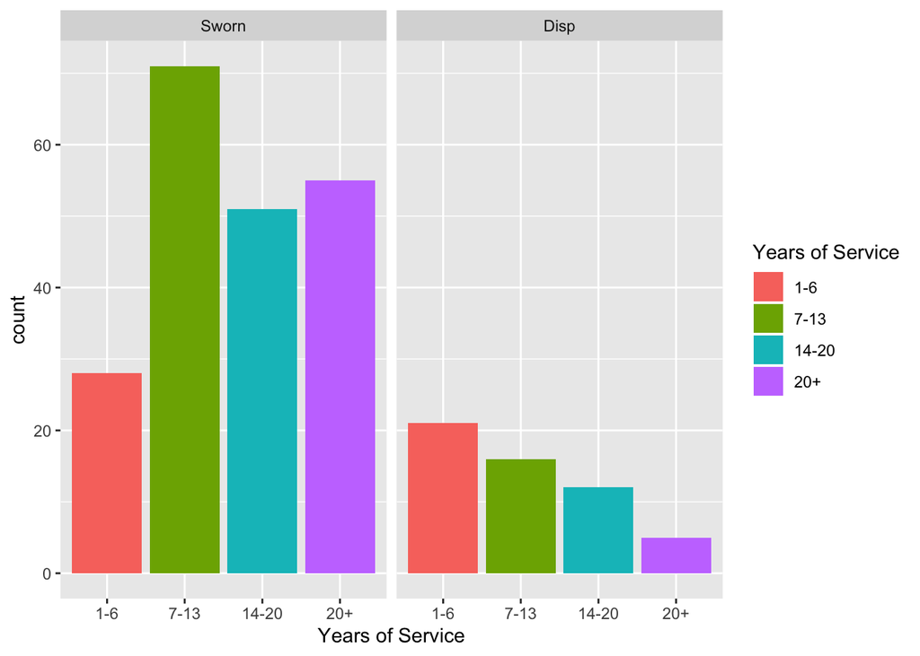

**Figure 1a.** *Distribution of the subject participating in the survey according to their position and time of service.*

```r
ggplot(df, aes(x= how.many.years, fill= factor(how.many.years))) +
  labs(x= "Years of Service", fill= "Years of Service") +
  geom_bar() +
  facet_grid(~Position)
```

#### Note:

- 2. Due to the steps are same for each secction. The Yelow section will serve as refference for the steps used to analysed the data.
- 1. Each section contains multiple stadistical models. To reduced the size of this document not all models will be graphed.

### Yellow

#### Programs Training or service already in place or potentially being considered

```r
dat <- read.csv("./Programs_Yellow1.cvs")
dat <- na.omit(dat)
dat$Years <- factor(dat$Years)
levels(dat$Years) <- c("1-6 years", "7-13 years", "14-20 years", "20+ years")
```

_ The steps are reproduceble for each section of the data. For convinience I created separete .cvs folders to access each section indivualy if needed.

### EPA

#### Step1

#### There are a couple of ways to visualize the survey data.

- Simple graphs

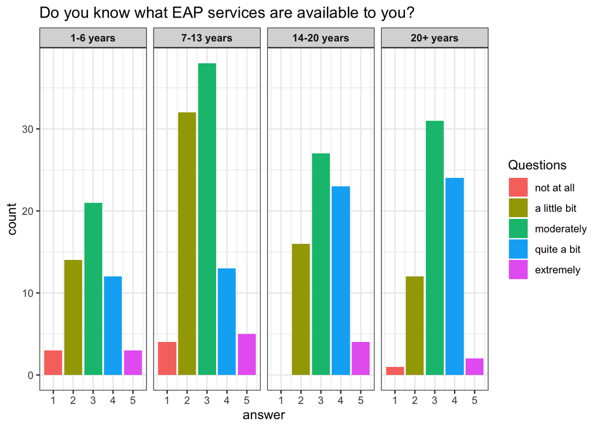

**Figure 2a.**Do you know what EAP services are available to you? Answers **

```r
ggplot(dat, aes(x= whatE, fill= factor(whatE))) +
  labs(x= "answer", title = "Do you know what EAP services are available to you?") +
  scale_fill_discrete(name = "Questions",
labels = c("not at all", "a little bit", "moderately", "quite a bit", "extremely")) +
  geom_bar() +
  theme_bw() +
  facet_grid(~Years) +
  theme(strip.text.x = element_text(face= "bold"))
```

- Tables

```r
#How Likely are you to use EAP Services
CrossTable(dat$Years,dat$likeE,prop.r=FALSE,prop.t=FALSE,prop.chisq=FALSE,format="SPSS")
```

```
##
##    Cell Contents
## |-------------------------|
## |                   Count |
## |          Column Percent |
## |-------------------------|
##
## Total Observations in Table:  285
##
##              | dat$likeE
##    dat$Years |        1  |        2  |        3  |        4  |        5  | Row Total |
## -------------|-----------|-----------|-----------|-----------|-----------|-----------|
##    1-6 years |        3  |       19  |       22  |        8  |        1  |       53  |
##              |    9.375% |   17.757% |   20.370% |   24.242% |   20.000% |           |
## -------------|-----------|-----------|-----------|-----------|-----------|-----------|
##   7-13 years |       10  |       37  |       36  |        7  |        2  |       92  |
##              |   31.250% |   34.579% |   33.333% |   21.212% |   40.000% |           |
## -------------|-----------|-----------|-----------|-----------|-----------|-----------|
##  14-20 years |        8  |       25  |       25  |       10  |        2  |       70  |
##              |   25.000% |   23.364% |   23.148% |   30.303% |   40.000% |           |
## -------------|-----------|-----------|-----------|-----------|-----------|-----------|
##    20+ years |       11  |       26  |       25  |        8  |        0  |       70  |
##              |   34.375% |   24.299% |   23.148% |   24.242% |    0.000% |           |
## -------------|-----------|-----------|-----------|-----------|-----------|-----------|
## Column Total |       32  |      107  |      108  |       33  |        5  |      285  |
##              |   11.228% |   37.544% |   37.895% |   11.579% |    1.754% |           |
## -------------|-----------|-----------|-----------|-----------|-----------|-----------|
##
##
```

- The table allows to have a numeric value for the responce “not at all” 11%, “a little bit” 37.5%, “moderately” 37.8% , “quite a bit” 11.6%, “extremely” 1.7%
- Both table and graph can be done for each individual question. (I am not sure what would you prefferer?)

#### Step2

#### Are this questions related?

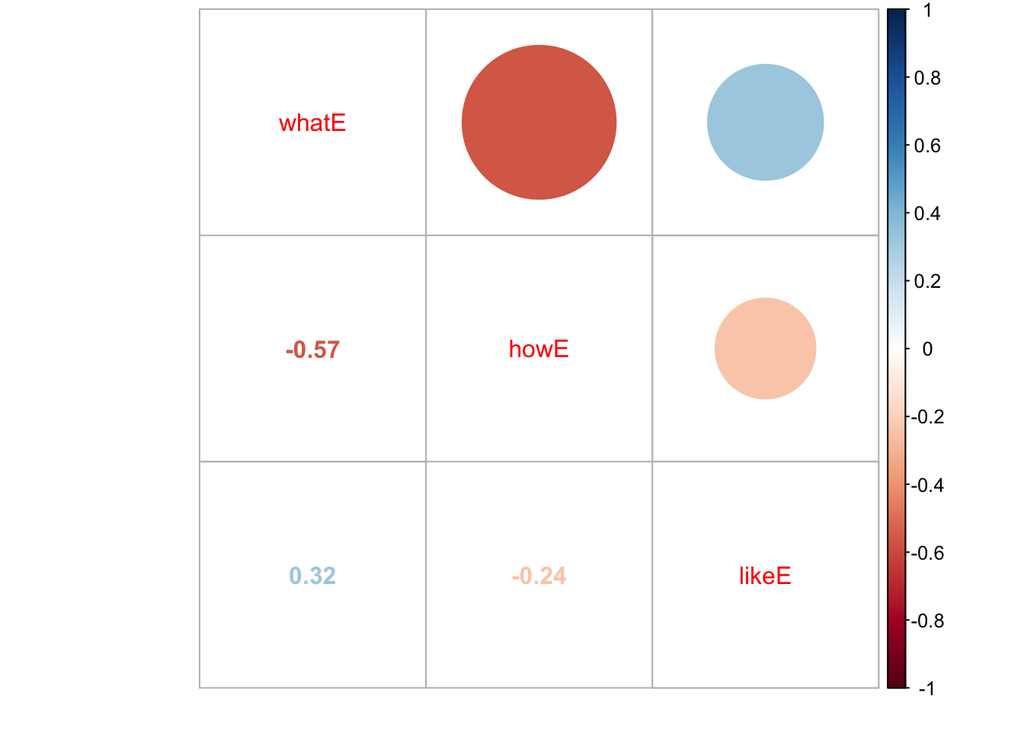

**Figure 2b.** *Correlation grph. EPA Qiestions*

```r
dat1 <- select(dat, whatE, howE, likeE)
dat1c <- cor(dat1)
corrplot.mixed(dat1c)
```

We can observe a positive and negative correlation. Models would depend in desired outcome of the data

#### Step4

#### Finding the best model

```r
mod1 <- lm(formula = likeE ~ whatE, data = dat)
mod2 <- lm(formula = likeE ~ howE, data = dat)
summary(mod2)#whatE is a better predictor to likeE
```

```
##
## Call:
## lm(formula = likeE ~ howE, data = dat)
##
## Residuals:
##     Min      1Q  Median      3Q     Max
## -1.7074 -0.7075  0.2925  0.7526  2.2925
##
## Coefficients:
##             Estimate Std. Error t value Pr(>|t|)
## (Intercept)   3.1675     0.1556  20.354  < 2e-16 ***
## howE         -0.4600     0.1095  -4.203 3.54e-05 ***
## ---
## Signif. codes:  0 '***' 0.001 '**' 0.01 '*' 0.05 '.' 0.1 ' ' 1
##
## Residual standard error: 0.8756 on 283 degrees of freedom
## Multiple R-squared:  0.05874,    Adjusted R-squared:  0.05542
## F-statistic: 17.66 on 1 and 283 DF,  p-value: 3.542e-05
```

```r
mod1mse <- mean(residuals(mod1)^2)
mod2mse <- mean(residuals(mod2)^2)
su2<- summary((mod2))$r.squared
su1<- summary((mod1))$r.squared
mod1mse ; mod2mse ; su1 ; su2
```

```
## [1] 0.725485
```

```
## [1] 0.7613033
```

```
## [1] 0.1030272
```

```
## [1] 0.05874243
```

whatE seems to be a beeter predictore for likeE. However, it explains only 10% of the varience.

#### Step5

#### Graphing models + predicctions

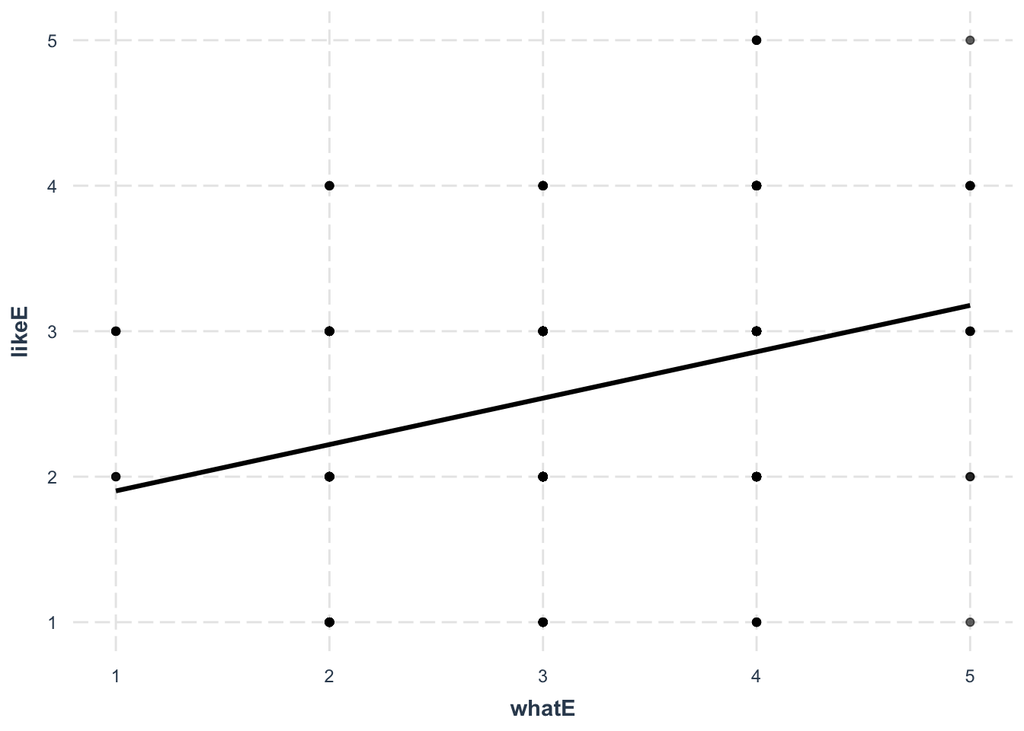

**Figure 2c.**Likely to usu EPA with respect What is EPA**

```r
effect_plot(mod1, pred = whatE, plot.points = TRUE, jitter = 0)
```

### Peer support

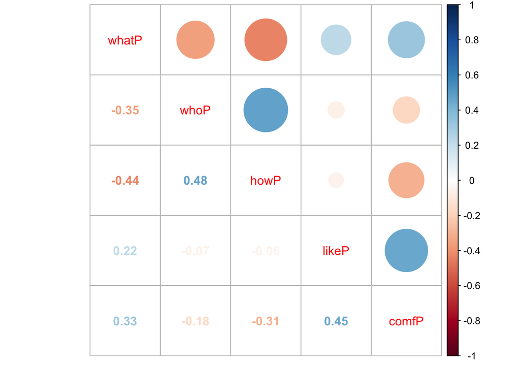

**Figure 3a.** *Correlation grph. Peer Support Qiestions*

```r
dat3 <- select(dat, whatP, whoP, howP, likeP, comfP)
dat3c <- cor(dat3)
corrplot.mixed(dat3c)
```

Best model previusly determined

```r
mod4 <- lm(data=dat3, formula = whoP ~ howP)
su4<- summary((mod4))$r.squared
mod4mse <- mean(residuals(mod4)^2)
mod4mse ; su4
```

```
## [1] 0.1427212
```

```
## [1] 0.2297322
```

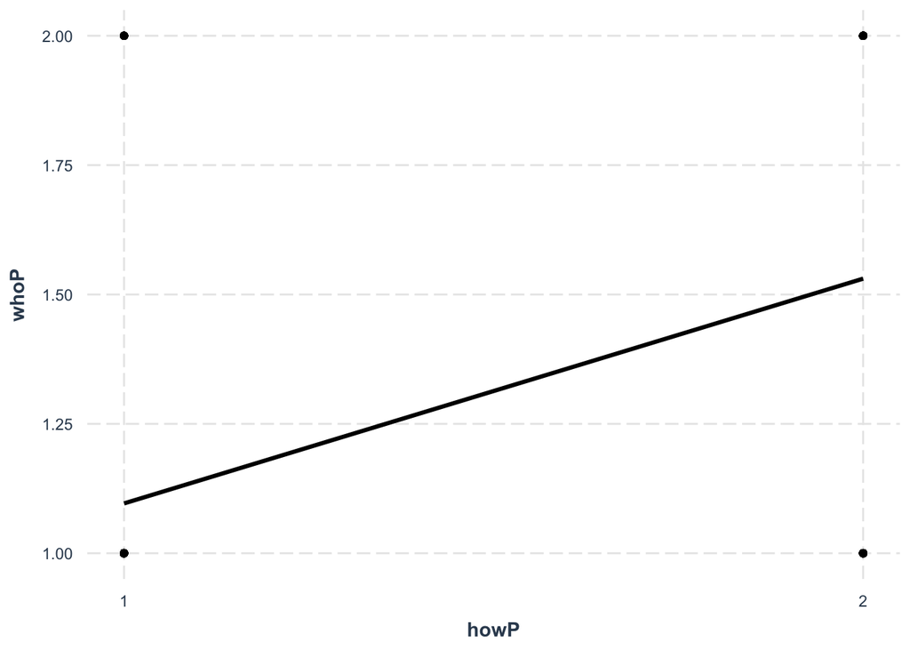

**Figure 3b.** *Correlation grph. Who is you peer support team? with respect How to access Peer support?*

```r
effect_plot(mod4, pred = howP, plot.points = TRUE, jitter = 0)
```

### In job Trainnings

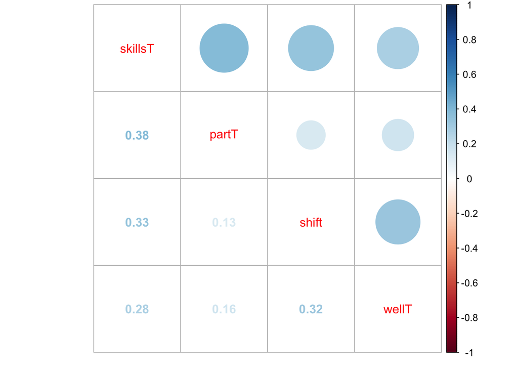

**Figure 4a.** *Correlation grph. In job Trainnings*

```r
dat4 <- select(dat, skillsT, partT, shift, wellT)
dat4c <- cor(dat4)
corrplot.mixed(dat4c)
```

```r
mod5 <- lm(data=dat4, formula = skillsT ~ partT)
su5<- summary((mod5))$r.squared
mod5mse <- mean(residuals(mod5)^2)
mod5mse ; su5
```

```
## [1] 0.8232622
```

```
## [1] 0.1457219
```

### Personal Workshops

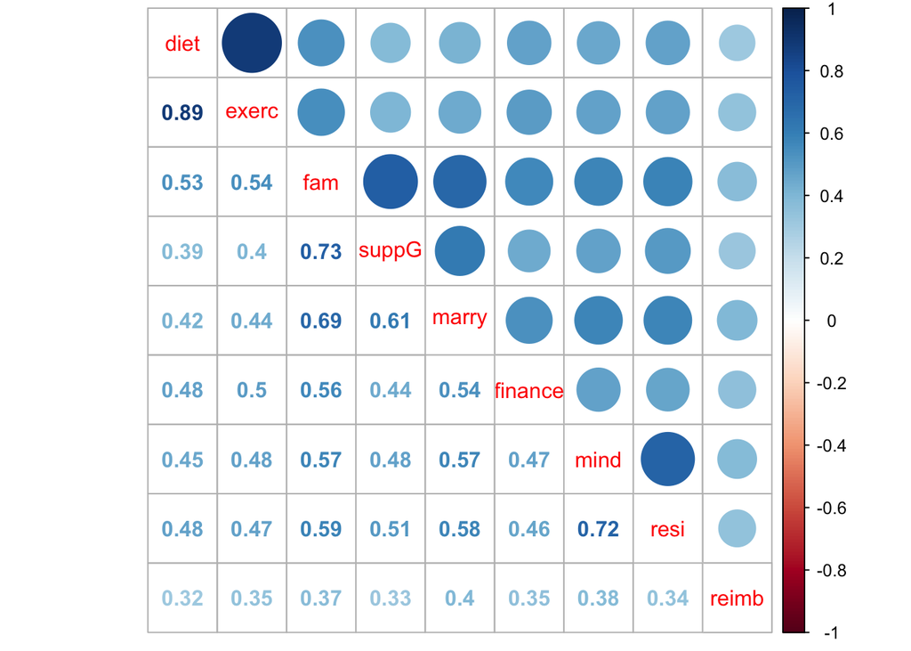

**Figure 5a.** *Correlation grph. Personal Workshops*

```r
dat5 <- select(dat, diet, exerc, fam, suppG, marry, finance, mind, resi, reimb)
dat5c <- cor(dat5)
corrplot.mixed(dat5c)
```

- Correlations seems to be stronger in this section

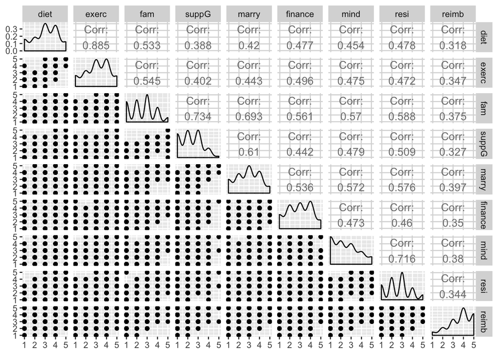

**Figure 5b.** *Correlation grph. Personal Workshops*

```r
ggpairs(dat5)
```

- Another way to see correlations with grphs instead of color coded.

```r
mod6 <- lm(data=dat5, formula = diet ~ exerc)
su6<- summary((mod6))$r.squared
mod6mse <- mean(residuals(mod6)^2)
mod6mse ; su6
```

```
## [1] 0.2992436
```

```
## [1] 0.7837077
```

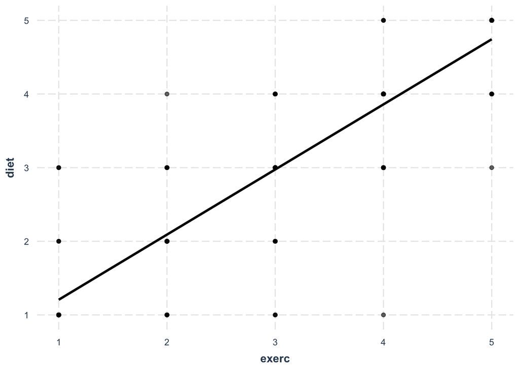

**Figure 5c.** *Correlation grph. Predicting Diet workshop attendace based on Exercise workshop attendace*

```r
effect_plot(mod6, pred = exerc, plot.points = TRUE, jitter = 0)
```

#### Blue

### Spiritual Impact

```r
df <- read.csv("./Programs_Blue.cvs")
df$how.many.years <- factor(df$how.many.years)
levels(df$how.many.years) <- c("1-6", "7-13", "14-20", "20+")
dfa <- subset(df, select = c(3:8))
```

```r
CrossTable(df$how.many.years,df$extent.spiritual,prop.r=FALSE,prop.t=FALSE,prop.chisq=FALSE,format="SPSS")
```

```
##
##    Cell Contents
## |-------------------------|
## |                   Count |
## |          Column Percent |
## |-------------------------|
##
## Total Observations in Table:  298
##
##                   | df$extent.spiritual
## df$how.many.years |        1  |        2  |        3  |        4  |        5  | Row Total |
## ------------------|-----------|-----------|-----------|-----------|-----------|-----------|
##               1-6 |       22  |        9  |       13  |        8  |        4  |       56  |
##                   |   25.581% |   24.324% |   16.667% |   10.959% |   16.667% |           |
## ------------------|-----------|-----------|-----------|-----------|-----------|-----------|
##              7-13 |       23  |       12  |       21  |       28  |       10  |       94  |
##                   |   26.744% |   32.432% |   26.923% |   38.356% |   41.667% |           |
## ------------------|-----------|-----------|-----------|-----------|-----------|-----------|
##             14-20 |       14  |       10  |       27  |       17  |        6  |       74  |
##                   |   16.279% |   27.027% |   34.615% |   23.288% |   25.000% |           |
## ------------------|-----------|-----------|-----------|-----------|-----------|-----------|
##               20+ |       27  |        6  |       17  |       20  |        4  |       74  |
##                   |   31.395% |   16.216% |   21.795% |   27.397% |   16.667% |           |
## ------------------|-----------|-----------|-----------|-----------|-----------|-----------|
##      Column Total |       86  |       37  |       78  |       73  |       24  |      298  |
##                   |   28.859% |   12.416% |   26.174% |   24.497% |    8.054% |           |
## ------------------|-----------|-----------|-----------|-----------|-----------|-----------|
##
##
```

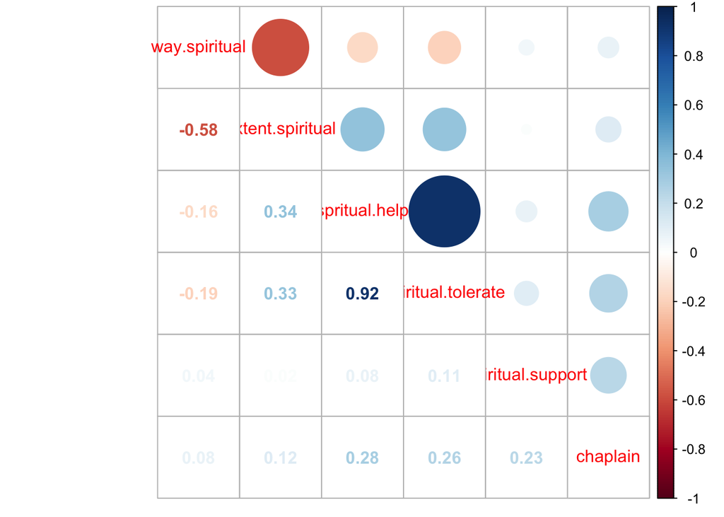

**Figure 10a.** *Correlation grph. Spiritual Impact Questions*

```r
dfac <- cor(dfa)
corrplot.mixed(dfac)
```

```r
moddf <- lm(data=df, formula = spritual.help ~ spiritual.tolerate)
sudf<- summary((moddf))$r.squared
moddfmse <- mean(residuals(moddf)^2)
moddfmse ; sudf
```

```
## [1] 0.3219105
```

```
## [1] 0.8518996
```

- Explains 85% of the varience

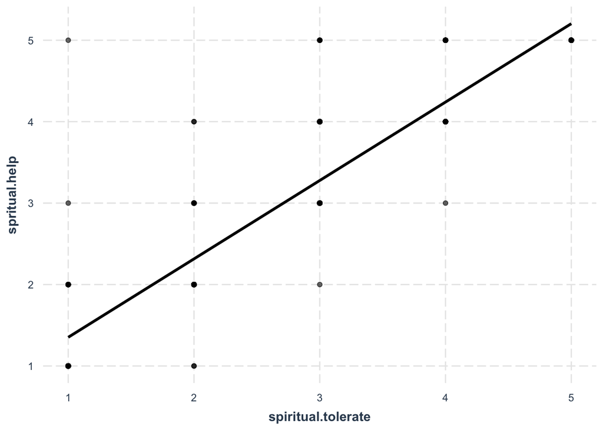

```r
effect_plot(moddf, pred = spiritual.tolerate, plot.points = TRUE, jitter = 0)
```

#### Red

### PTSD, Depression, Anxiety and Suicidal Measures

```r
dfr <- read.csv("./Programs_Red.cvs")
dfr$how.many.years <- factor(dfr$how.many.years)
levels(dfr$how.many.years) <- c("1-6", "7-13", "14-20", "20+")
```

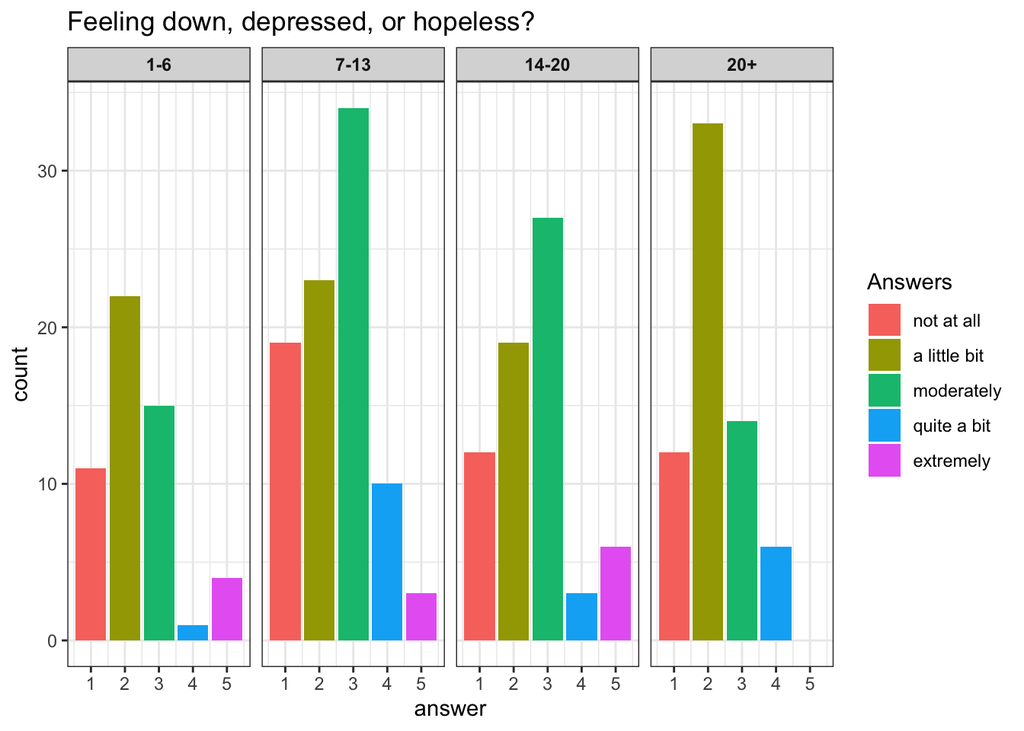

**Figure 12a.** *Feeling down, depressed, or hopeless? Answer rate*

```r
ggplot(dfr, aes(x= feeling.depressed , fill= factor(feeling.depressed))) +
  labs(x= "answer", title = "Feeling down, depressed, or hopeless?") +
  scale_fill_discrete(name = "Answers",
labels = c("not at all", "a little bit", "moderately", "quite a bit", "extremely")) +
  geom_bar() +
  theme_bw() +
  facet_grid(~how.many.years) +
  theme(strip.text.x = element_text(face= "bold"))
```

```r
CrossTable(dfr$how.many.years,dfr$feeling.depressed,prop.r=FALSE,prop.t=FALSE,prop.chisq=FALSE,format="SPSS")
```

```
##
##    Cell Contents
## |-------------------------|
## |                   Count |
## |          Column Percent |
## |-------------------------|
##
## Total Observations in Table:  274
##
##                    | dfr$feeling.depressed
## dfr$how.many.years |        1  |        2  |        3  |        4  |        5  | Row Total |
## -------------------|-----------|-----------|-----------|-----------|-----------|-----------|
##                1-6 |       11  |       22  |       15  |        1  |        4  |       53  |
##                    |   20.370% |   22.680% |   16.667% |    5.000% |   30.769% |           |
## -------------------|-----------|-----------|-----------|-----------|-----------|-----------|
##               7-13 |       19  |       23  |       34  |       10  |        3  |       89  |
##                    |   35.185% |   23.711% |   37.778% |   50.000% |   23.077% |           |
## -------------------|-----------|-----------|-----------|-----------|-----------|-----------|
##              14-20 |       12  |       19  |       27  |        3  |        6  |       67  |
##                    |   22.222% |   19.588% |   30.000% |   15.000% |   46.154% |           |
## -------------------|-----------|-----------|-----------|-----------|-----------|-----------|
##                20+ |       12  |       33  |       14  |        6  |        0  |       65  |
##                    |   22.222% |   34.021% |   15.556% |   30.000% |    0.000% |           |
## -------------------|-----------|-----------|-----------|-----------|-----------|-----------|
##       Column Total |       54  |       97  |       90  |       20  |       13  |      274  |
##                    |   19.708% |   35.401% |   32.847% |    7.299% |    4.745% |           |
## -------------------|-----------|-----------|-----------|-----------|-----------|-----------|
##
##
```

#### Orange

### Barriers to getting help

```r
dfo <- read.csv("./Programs_Orange.cvs")
dfo$how.many.years <- factor(dfo$how.many.years)
levels(dfo$how.many.years) <- c("1-6", "7-13", "14-20", "20+")
```

```r
CrossTable(dfo$how.many.years,dfo$I.might.need,prop.r=FALSE,prop.t=FALSE,prop.chisq=FALSE,format="SPSS")
```

```
##
##    Cell Contents
## |-------------------------|
## |                   Count |
## |          Column Percent |
## |-------------------------|
##
## Total Observations in Table:  296
##
##                    | dfo$I.might.need
## dfo$how.many.years |        1  |        2  |        3  |        4  |        5  | Row Total |
## -------------------|-----------|-----------|-----------|-----------|-----------|-----------|
##                1-6 |        5  |        7  |       12  |       25  |        5  |       54  |
##                    |   18.519% |   14.000% |   16.667% |   21.552% |   16.129% |           |
## -------------------|-----------|-----------|-----------|-----------|-----------|-----------|
##               7-13 |        7  |       14  |       18  |       42  |       13  |       94  |
##                    |   25.926% |   28.000% |   25.000% |   36.207% |   41.935% |           |
## -------------------|-----------|-----------|-----------|-----------|-----------|-----------|
##              14-20 |        7  |       12  |       20  |       26  |        9  |       74  |
##                    |   25.926% |   24.000% |   27.778% |   22.414% |   29.032% |           |
## -------------------|-----------|-----------|-----------|-----------|-----------|-----------|
##                20+ |        8  |       17  |       22  |       23  |        4  |       74  |
##                    |   29.630% |   34.000% |   30.556% |   19.828% |   12.903% |           |
## -------------------|-----------|-----------|-----------|-----------|-----------|-----------|
##       Column Total |       27  |       50  |       72  |      116  |       31  |      296  |
##                    |    9.122% |   16.892% |   24.324% |   39.189% |   10.473% |           |
## -------------------|-----------|-----------|-----------|-----------|-----------|-----------|
##
##
```

- Almost 40% of personal has wonder if they need mental health

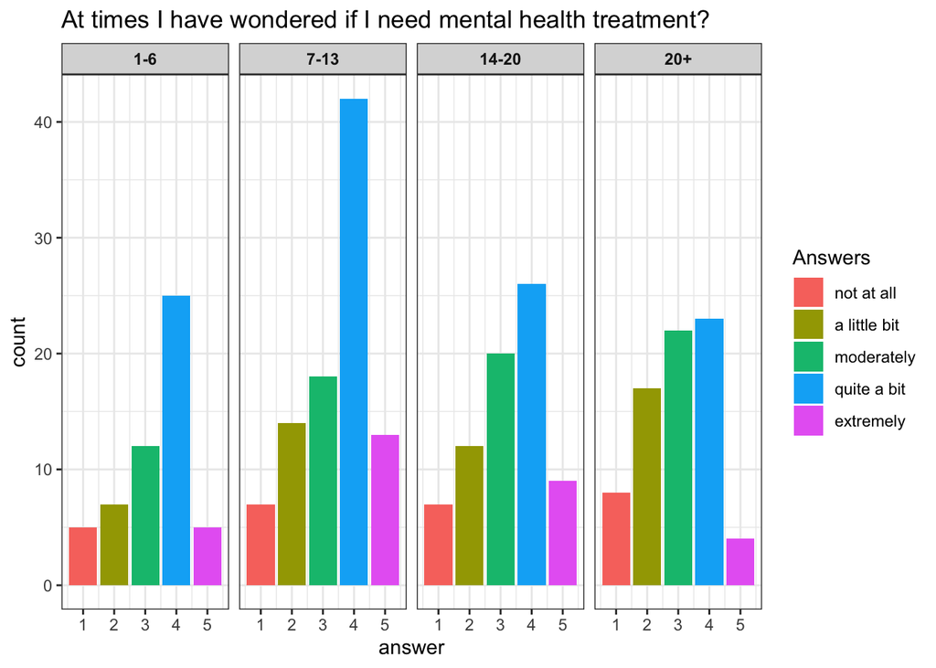

**Figure 13a.** *At times I have wondered if I need mental health treatment? Answer rate*

```r
ggplot(dfo, aes(x= I.might.need , fill= factor(I.might.need))) +
  labs(x= "answer", title = "At times I have wondered if I need mental health treatment?") +
  scale_fill_discrete(name = "Answers",
labels = c("not at all", "a little bit", "moderately", "quite a bit", "extremely")) +
  geom_bar() +
  theme_bw() +
  facet_grid(~how.many.years) +
  theme(strip.text.x = element_text(face= "bold"))
```

#### Purple

### Coping

```r
dfp <- read.csv("./Programs_Purple.cvs")
dfp$how.many.years <- factor(dfp$how.many.years)
levels(dfp$how.many.years) <- c("1-6", "7-13", "14-20", "20+")
```

```r
CrossTable(dfp$how.many.years,dfp$how.often.alcohol,prop.r=FALSE,prop.t=FALSE,prop.chisq=FALSE,format="SPSS")
```

```
##
##    Cell Contents
## |-------------------------|
## |                   Count |
## |          Column Percent |
## |-------------------------|
##
## Total Observations in Table:  300
##
##                    | dfp$how.often.alcohol
## dfp$how.many.years |        1  |        2  |        3  |        4  |        5  | Row Total |
## -------------------|-----------|-----------|-----------|-----------|-----------|-----------|
##                1-6 |       33  |       13  |        9  |        1  |        0  |       56  |
##                    |   18.333% |   19.697% |   28.125% |    6.667% |    0.000% |           |
## -------------------|-----------|-----------|-----------|-----------|-----------|-----------|
##               7-13 |       59  |       21  |        9  |        3  |        2  |       94  |
##                    |   32.778% |   31.818% |   28.125% |   20.000% |   28.571% |           |
## -------------------|-----------|-----------|-----------|-----------|-----------|-----------|
##              14-20 |       41  |       18  |        9  |        5  |        1  |       74  |
##                    |   22.778% |   27.273% |   28.125% |   33.333% |   14.286% |           |
## -------------------|-----------|-----------|-----------|-----------|-----------|-----------|
##                20+ |       47  |       14  |        5  |        6  |        4  |       76  |
##                    |   26.111% |   21.212% |   15.625% |   40.000% |   57.143% |           |
## -------------------|-----------|-----------|-----------|-----------|-----------|-----------|
##       Column Total |      180  |       66  |       32  |       15  |        7  |      300  |
##                    |   60.000% |   22.000% |   10.667% |    5.000% |    2.333% |           |
## -------------------|-----------|-----------|-----------|-----------|-----------|-----------|
##
##
```

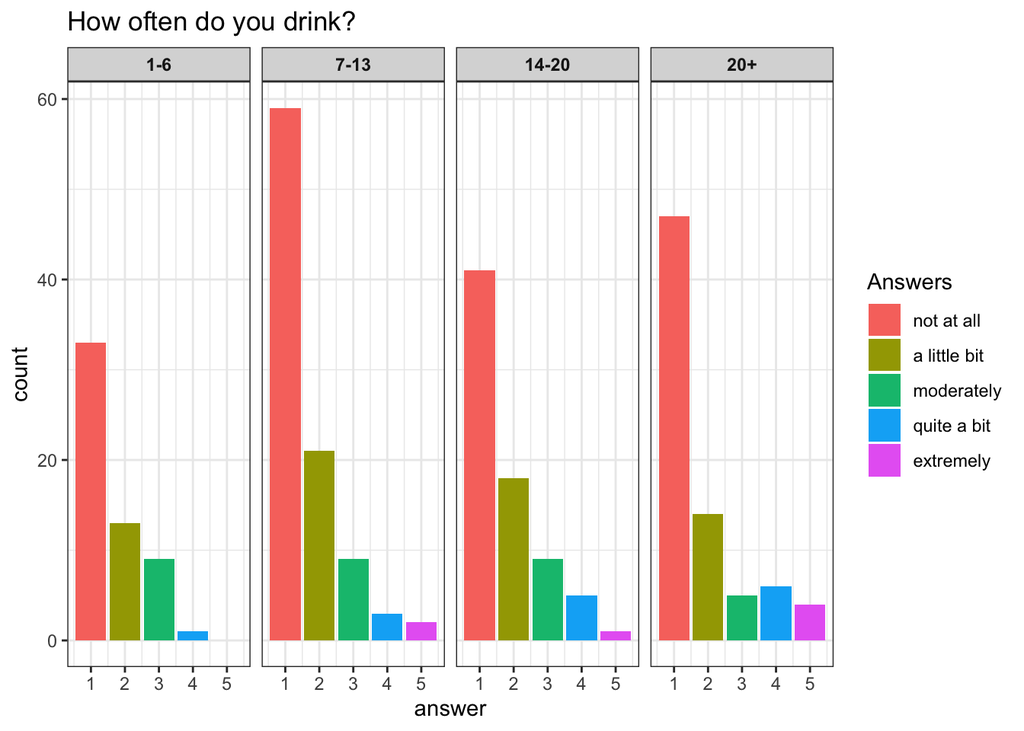

**Figure 14a.** *How often do you drink? Answer rate*

```r
names(dfp)
ggplot(dfp, aes(x= how.often.alcohol , fill= factor(how.often.alcohol))) +
  labs(x= "answer", title = "How often do you drink?") +
  scale_fill_discrete(name = "Answers",
labels = c("not at all", "a little bit", "moderately", "quite a bit", "extremely")) +
  geom_bar() +
  theme_bw() +
  facet_grid(~how.many.years) +
  theme(strip.text.x = element_text(face= "bold"))
```